Name: Sajjad Alizadeh  
STD number: 810197547  
Subject: AI-CA0 report and code

پروژه صفر: آشنایی با هوش مصنوعی  
هدف از این پروژه پر کردن نواقص یک دیتاست با پیش بینی آنها به کمک تحلیل آماری است.  
در این پروژه داده هزار کاربر که از یک سایت بازدید کرده اند جمع آوری شده است. در این سایت یک آگهی تبلیغاتی وجود داشته و یکی از اطلاعاتی که در مورد این کاربران داریم این است که آیا یک کاربر بر روی این آگهی کلیک کرده است یا خیر. اما این رکورد برای بعضی کاربران وجود ندارد. حال میخواهیم با استفاده از تحلیل آماری پیش بینی کنیم که آیا کاربرانی که این رکورد از داده برای آنها موجود نیست بر روی تبلیغ کلیک کرده اند یا خیر. در این پروژه عمدتا از کتابخانه های numpy و pandas استفاده شده است.

# PART 1

```python
import pandas

file_content = pandas.read_csv("advertising_dataset.csv")
print("\nhead method\n===========================\n")
print(file_content.head(2))
print("\ntail method\n===========================\n")
print(file_content.tail(1))
print("\ndescribe method\n===========================\n")
print(file_content.describe)
```

```
head method
===========================

   Unnamed: 0  Daily Time Spent on Site   Age  Area Income  \
0           0                     68.95  35.0     61833.90
1           1                     80.23  31.0     68441.85

   Daily Internet Usage                       Ad Topic Line         City  \
0                256.09  Cloned 5thgeneration orchestration  Wrightburgh
1                   NaN  Monitored national standardization    West Jodi

   Gender  Country            Timestamp  Clicked on Ad
0  Female  Tunisia  2016-03-27 00:53:11            0.0
1    Male    Nauru  2016-04-04 01:39:02            0.0

tail method
===========================

     Unnamed: 0  Daily Time Spent on Site   Age  Area Income  \
999         999                       NaN  26.0      29875.8

     Daily Internet Usage                    Ad Topic Line         City  \
999                178.35  Virtual 5thgeneration emulation  Ronniemouth

     Gender Country            Timestamp  Clicked on Ad
999  Female  Brazil  2016-06-03 21:43:21            1.0

describe method
===========================

<bound method NDFrame.describe of      Unnamed: 0  Daily Time Spent on Site   Age  Area Income  \
0             0                     68.95  35.0     61833.90
1             1                     80.23  31.0     68441.85
2             2                     69.47  26.0     59785.94
3             3                     74.15  29.0     54806.18
4             4                     68.37  35.0     73889.99
..          ...                       ...   ...          ...
995         995                     72.97  30.0     71384.57
996         996                     51.30  45.0     67782.17
997         997                     51.63  51.0     42415.72
```

[output cut: 28 more lines]

```

     Clicked on Ad
0              0.0
1              0.0
2              0.0
3              0.0
4              0.0
..             ...
995            1.0
996            1.0
997            1.0
998            0.0
999            1.0

[1000 rows x 11 columns]>
```

Description:

head(n): Returns the first n rows of the caller object.  
tail(n): Returns the last n rows of the caller object.  
describe(): Summary statistics of the Dataframe provided.

# PART 2

```python
import pandas

file_content = pandas.read_csv("advertising_dataset.csv")
print(file_content.info())
```

```
<class 'pandas.core.frame.DataFrame'>
RangeIndex: 1000 entries, 0 to 999
Data columns (total 11 columns):
 #   Column                    Non-Null Count  Dtype
---  ------                    --------------  -----
 0   Unnamed: 0                1000 non-null   int64
 1   Daily Time Spent on Site  907 non-null    float64
 2   Age                       979 non-null    float64
 3   Area Income               1000 non-null   float64
 4   Daily Internet Usage      913 non-null    float64
 5   Ad Topic Line             1000 non-null   object
 6   City                      1000 non-null   object
 7   Gender                    1000 non-null   object
 8   Country                   1000 non-null   object
 9   Timestamp                 1000 non-null   object
 10  Clicked on Ad             832 non-null    float64
dtypes: float64(5), int64(1), object(5)
memory usage: 86.1+ KB
None
```

نوع داده هر ستون مشخص است  
حال به جای Female عدد صفر و به جای Male عدد یک را جایگذاری میکنیم. این کار را implace انجام میدهیم تا در همان دیتافریمی که از فایل ساخته شده تغییرات اعمال شود.

```python
import pandas

file_content = pandas.read_csv("advertising_dataset.csv")
file_content['Gender'].replace('Male', 1, inplace=True)
file_content['Gender'].replace('Female', 0, inplace=True)
print(file_content.head(4))
```

```
   Unnamed: 0  Daily Time Spent on Site   Age  Area Income  \
0           0                     68.95  35.0     61833.90
1           1                     80.23  31.0     68441.85
2           2                     69.47  26.0     59785.94
3           3                     74.15  29.0     54806.18

   Daily Internet Usage                          Ad Topic Line  \
0                256.09     Cloned 5thgeneration orchestration
1                   NaN     Monitored national standardization
2                236.50       Organic bottom-line service-desk
3                245.89  Triple-buffered reciprocal time-frame

             City  Gender     Country            Timestamp  Clicked on Ad
0     Wrightburgh       0     Tunisia  2016-03-27 00:53:11            0.0
1       West Jodi       1       Nauru  2016-04-04 01:39:02            0.0
2        Davidton       0  San Marino  2016-03-13 20:35:42            0.0
3  West Terrifurt       1       Italy  2016-01-10 02:31:19            0.0
```

همانطور که مشاهده میشود وقتی چهار داده اول را چاپ میکنیم مقدار مورد نظر ما تغییر کرده است.

# PART 3

تعداد داده هایی که موجود نیستند به شکل زیر است.

```python
import pandas

file_content = pandas.read_csv("advertising_dataset.csv")
for i in file_content.columns:
    print("Number of NaN", i, ":", file_content[i].isna().sum())
```

```
Number of NaN Unnamed: 0 : 0
Number of NaN Daily Time Spent on Site : 93
Number of NaN Age : 21
Number of NaN Area Income : 0
Number of NaN Daily Internet Usage : 87
Number of NaN Ad Topic Line : 0
Number of NaN City : 0
Number of NaN Gender : 0
Number of NaN Country : 0
Number of NaN Timestamp : 0
Number of NaN Clicked on Ad : 168
```

قطعه کد زیر مقادیری را که موجود نیستند با میانگین جایگذاری میکند.

```python
import pandas
file_content = pandas.read_csv("advertising_dataset.csv")
for i in file_content.columns[1:5]:
    file_content[i].fillna(file_content[i].mean(), inplace=True)
file_content
```

|  | Unnamed: 0 | Daily Time Spent on Site | Age | Area Income | Daily Internet Usage | Ad Topic Line | City | Gender | Country | Timestamp | Clicked on Ad |
| --- | --- | --- | --- | --- | --- | --- | --- | --- | --- | --- | --- |
| 0 | 0 | 68.950000 | 35.0 | 61833.90 | 256.090000 | Cloned 5thgeneration orchestration | Wrightburgh | Female | Tunisia | 2016-03-27 00:53:11 | 0.0 |
| 1 | 1 | 80.230000 | 31.0 | 68441.85 | 179.751271 | Monitored national standardization | West Jodi | Male | Nauru | 2016-04-04 01:39:02 | 0.0 |
| 2 | 2 | 69.470000 | 26.0 | 59785.94 | 236.500000 | Organic bottom-line service-desk | Davidton | Female | San Marino | 2016-03-13 20:35:42 | 0.0 |
| 3 | 3 | 74.150000 | 29.0 | 54806.18 | 245.890000 | Triple-buffered reciprocal time-frame | West Terrifurt | Male | Italy | 2016-01-10 02:31:19 | 0.0 |
| 4 | 4 | 68.370000 | 35.0 | 73889.99 | 225.580000 | Robust logistical utilization | South Manuel | Female | Iceland | 2016-06-03 03:36:18 | 0.0 |
| ... | ... | ... | ... | ... | ... | ... | ... | ... | ... | ... | ... |
| 995 | 995 | 72.970000 | 30.0 | 71384.57 | 208.580000 | Fundamental modular algorithm | Duffystad | Male | Lebanon | 2016-02-11 21:49:00 | 1.0 |
| 996 | 996 | 51.300000 | 45.0 | 67782.17 | 134.420000 | Grass-roots cohesive monitoring | New Darlene | Male | Bosnia and Herzegovina | 2016-04-22 02:07:01 | 1.0 |
| 997 | 997 | 51.630000 | 51.0 | 42415.72 | 120.370000 | Expanded intangible solution | South Jessica | Male | Mongolia | 2016-02-01 17:24:57 | 1.0 |
| 998 | 998 | 55.550000 | 19.0 | 41920.79 | 187.950000 | Proactive bandwidth-monitored policy | West Steven | Female | Guatemala | 2016-03-24 02:35:54 | 0.0 |
| 999 | 999 | 64.794818 | 26.0 | 29875.80 | 178.350000 | Virtual 5thgeneration emulation | Ronniemouth | Female | Brazil | 2016-06-03 21:43:21 | 1.0 |

1000 rows × 11 columns

روش دیگری که به ذهن بنده میرسد در نظر نگرفتن خانه های NaN هنگام محاسبه یک ویژگی است. در روش قبلی به عنوان مثال اگر بیست درصد داده ها موجود نباشند جایگزین کردن آن ها با میانگین ممکن است باعث تغییرات چشمگیری شود.  
اگر جایگزین کردن حتما باید انجام شود میتوان از میانه که معیار بهتری است استفاده کرد. زیرا داده های پرت کمتر روی آن تاثیرگذار هستند.

# PART 4

```python
import pandas

file_content = pandas.read_csv("advertising_dataset.csv")
file_content['Gender'].replace('Male', 1, inplace=True)
file_content['Gender'].replace('Female', 0, inplace=True)


print("Number of male people:", len(file_content[file_content['Gender'] == 1]))
print("Number of female people:", len(file_content[file_content['Gender'] == 0]))
print("People who clicked on ad:", len(file_content[file_content['Clicked on Ad'] == 1]))
print("People who did not click on ad:", len(file_content[file_content['Clicked on Ad'] == 0]))
```

```
Number of male people: 481
Number of female people: 519
People who clicked on ad: 413
People who did not click on ad: 419
```

# PART 5

```python
import pandas
import numpy

file_content = pandas.read_csv("advertising_dataset.csv")
file_content['Gender'].replace('Male', 1, inplace=True)
file_content['Gender'].replace('Female', 0, inplace=True)
for i in file_content.columns[1:5]:
    file_content[i].fillna(file_content[i].mean(), inplace=True)

my_gender = 1
my_age = 20
print("My gender, older:", len(file_content[numpy.logical_and(file_content['Age'] > my_age, file_content['Gender'] == my_gender)]))
```

```
My gender, older: 472
```

توجه کنید در قطعه کد بالا به جای داده هایی که موجود نبودند میانگین آن داده ها قرار داده شده است

# PART 6

```python
import pandas
import time

file_content = pandas.read_csv("advertising_dataset.csv")
for i in file_content.columns[1:5]:
    file_content[i].fillna(file_content[i].mean(), inplace=True)

tic = time.time()
click = file_content.groupby('Clicked on Ad')['Age'].mean()[1]
toc = time.time()
print("Average age of people who clicked on the ad (took %f ms):" % ((toc - tic) * 1000), click)

tic = time.time()
no_click = file_content.groupby('Clicked on Ad')['Age'].mean()[0]
toc = time.time()
print("Average age of people who did not click on the ad (took %f ms):" % ((toc - tic) * 1000), no_click)
```

```
Average age of people who clicked on the ad (took 1.084566 ms): 40.295599848637366
Average age of people who did not click on the ad (took 1.496077 ms): 31.723325881701896
```

زمان محاسبه این مقدار داخل پرانتز نوشته شده است  
توجه کنید در قطعه کد بالا به جای داده هایی که موجود نبودند میانگین آن داده ها قرار داده شده است

# PART 7

```python
import pandas
import time

file_content = pandas.read_csv("advertising_dataset.csv")
for i in file_content.columns[1:5]:
    file_content[i].fillna(file_content[i].mean(), inplace=True)
tic = time.time()
click = 0
no_click = 0
num_of_click = 0;
num_of_no_click = 0;
for i in range(1000):
    if file_content['Clicked on Ad'][i] == 0:
        no_click += file_content['Age'][i]
        num_of_no_click += 1
toc = time.time()
print("Average age of people who did not click on the ad (took %f ms):" % ((toc - tic) * 1000), no_click / num_of_no_click)

tic = time.time()
for i in range(1000):
    if file_content['Clicked on Ad'][i] == 1:
        click += file_content['Age'][i]
        num_of_click += 1
toc = time.time()
print("Average age of people who clicked on the ad (took %f ms):" % ((toc - tic) * 1000), click / num_of_click)
```

```
Average age of people who did not click on the ad (took 9.881020 ms): 31.723325881701896
Average age of people who clicked on the ad (took 10.023832 ms): 40.295599848637366
```

زمان محاسبه این مقدار داخل پرانتز نوشته شده است.  
در این حالت چندین برابر بیشتر طول میکشد تا نتیجه محاسبه شود.

# PART 8

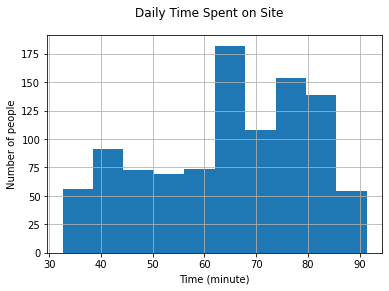

```python
import pandas
import matplotlib.pyplot as plt

file_content = pandas.read_csv("advertising_dataset.csv")
for i in file_content.columns[1:5]:
    file_content[i].fillna(file_content[i].mean(), inplace=True)

ax = file_content['Daily Time Spent on Site'].hist()
plt.suptitle("Daily Time Spent on Site")
ax.set_xlabel("Time (minute)")
ax.set_ylabel("Number of people")
```

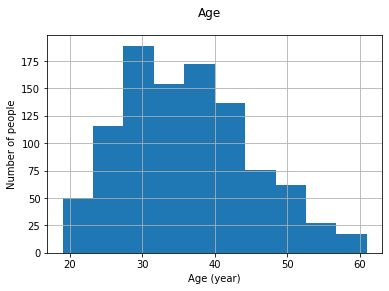

```python
import pandas
import matplotlib.pyplot as plt

file_content = pandas.read_csv("advertising_dataset.csv")
for i in file_content.columns[1:5]:
    file_content[i].fillna(file_content[i].mean(), inplace=True)

ax = file_content['Age'].hist()
plt.suptitle("Age")
ax.set_xlabel("Age (year)")
ax.set_ylabel("Number of people")
```

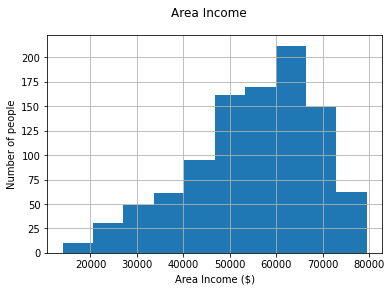

```python
import pandas
import matplotlib.pyplot as plt

file_content = pandas.read_csv("advertising_dataset.csv")
for i in file_content.columns[1:5]:
    file_content[i].fillna(file_content[i].mean(), inplace=True)

ax = file_content['Area Income'].hist()
plt.suptitle("Area Income")
ax.set_xlabel("Area Income ($)")
ax.set_ylabel("Number of people")
```

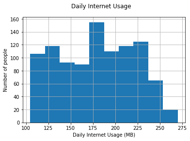

```python
import pandas
import matplotlib.pyplot as plt

file_content = pandas.read_csv("advertising_dataset.csv")
for i in file_content.columns[1:5]:
    file_content[i].fillna(file_content[i].mean(), inplace=True)

ax = file_content['Daily Internet Usage'].hist()
plt.suptitle("Daily Internet Usage")
ax.set_xlabel("Daily Internet Usage (MB)")
ax.set_ylabel("Number of people")
```

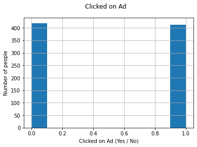

```python
import pandas
import matplotlib.pyplot as plt

file_content = pandas.read_csv("advertising_dataset.csv")
for i in file_content.columns[1:5]:
    file_content[i].fillna(file_content[i].mean(), inplace=True)

ax = file_content['Clicked on Ad'].hist()
plt.suptitle("Clicked on Ad")
ax.set_xlabel("Clicked on Ad (Yes / No)")
ax.set_ylabel("Number of people")
```

توجه کنید در قطعه کد بالا به جای داده هایی که موجود نبودند میانگین آن داده ها قرار داده شده است  
از کتابخانه matplotlib.pyplot جهت اضافه کردن title به نمودارها استفاده شده است

# PART 9

```python
import pandas

file_content = pandas.read_csv("advertising_dataset.csv")
temp = file_content['Clicked on Ad']
file_content.drop(columns = ['Unnamed: 0', 'Ad Topic Line', 'City', 'Gender', 'Country', 'Timestamp'], inplace=True)
file_content = (file_content - file_content.mean()) / file_content.std()
file_content['Clicked on Ad'] = temp
file_content
```

|  | Daily Time Spent on Site | Age | Area Income | Daily Internet Usage | Clicked on Ad |
| --- | --- | --- | --- | --- | --- |
| 0 | 0.260434 | -0.114895 | 0.509436 | 1.736631 | 0.0 |
| 1 | 0.967429 | -0.570287 | 1.002029 | NaN | 0.0 |
| 2 | 0.293026 | -1.139527 | 0.356770 | 1.290978 | 0.0 |
| 3 | 0.586354 | -0.797983 | -0.014448 | 1.504591 | 0.0 |
| 4 | 0.224081 | -0.114895 | 1.408163 | 1.042559 | 0.0 |
| ... | ... | ... | ... | ... | ... |
| 995 | 0.512395 | -0.684135 | 1.221395 | 0.655825 | 1.0 |
| 996 | -0.845813 | 1.023586 | 0.952853 | -1.031242 | 1.0 |
| 997 | -0.825130 | 1.706674 | -0.938101 | -1.350866 | 1.0 |
| 998 | -0.579437 | -1.936464 | -0.974996 | 0.186513 | 0.0 |
| 999 | NaN | -1.139527 | -1.872895 | -0.031878 | 1.0 |

1000 rows × 5 columns

در کد این قسمت برای مقادیر NaN جایگزینی در نظر نگرفته شده است و این مقادیر خالی میمانند.  
اگر این مقادیر را خالی نگذاریم به جدول زیر خواهیم رسید:

```python
import pandas

file_content = pandas.read_csv("advertising_dataset.csv")
for i in file_content.columns[1:5]:
    file_content[i].fillna(file_content[i].mean(), inplace=True)
temp = file_content['Clicked on Ad']
file_content.drop(columns = ['Unnamed: 0', 'Ad Topic Line', 'City', 'Gender', 'Country', 'Timestamp'], inplace=True)
file_content = (file_content - file_content.mean()) / file_content.std()
file_content['Clicked on Ad'] = temp
file_content
```

|  | Daily Time Spent on Site | Age | Area Income | Daily Internet Usage | Clicked on Ad |
| --- | --- | --- | --- | --- | --- |
| 0 | 2.734741e-01 | -0.116122 | 0.509436 | 1.817578e+00 | 0.0 |
| 1 | 1.015870e+00 | -0.576377 | 1.002029 | -1.353406e-15 | 0.0 |
| 2 | 3.076980e-01 | -1.151696 | 0.356770 | 1.351152e+00 | 0.0 |
| 3 | 6.157131e-01 | -0.806505 | -0.014448 | 1.574722e+00 | 0.0 |
| 4 | 2.353013e-01 | -0.116122 | 1.408163 | 1.091154e+00 | 0.0 |
| ... | ... | ... | ... | ... | ... |
| 995 | 5.380512e-01 | -0.691441 | 1.221395 | 6.863941e-01 | 1.0 |
| 996 | -8.881641e-01 | 1.034517 | 0.952853 | -1.079309e+00 | 1.0 |
| 997 | -8.664451e-01 | 1.724900 | -0.938101 | -1.413831e+00 | 1.0 |
| 998 | -6.084495e-01 | -1.957144 | -0.974996 | 1.952066e-01 | 0.0 |
| 999 | -4.676451e-15 | -1.151696 | -1.872895 | -3.336338e-02 | 1.0 |

1000 rows × 5 columns

# PART 10

```
Daily Time Spent on Site: (BLUE: clicked, ORANGE: Not clicked)
```

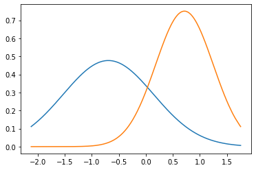

```python
import pandas
import numpy
import scipy.stats
import matplotlib.pyplot as plt

file_content = pandas.read_csv("advertising_dataset.csv")
# Replace NaNs
for i in file_content.columns[1:5]:
    file_content[i].fillna(file_content[i].mean(), inplace=True)
# Normalize
temp = file_content['Clicked on Ad']
file_content.drop(columns = ['Unnamed: 0', 'Ad Topic Line', 'City', 'Gender', 'Country', 'Timestamp'], inplace=True)
file_content = (file_content - file_content.mean()) / file_content.std()
file_content['Clicked on Ad'] = temp


mean_click = file_content.groupby('Clicked on Ad')['Daily Time Spent on Site'].mean()[1]
mean_not_click = file_content.groupby('Clicked on Ad')['Daily Time Spent on Site'].mean()[0]
std_click = file_content.groupby('Clicked on Ad')['Daily Time Spent on Site'].std()[1]
std_not_click = file_content.groupby('Clicked on Ad')['Daily Time Spent on Site'].std()[0]

norm_click = scipy.stats.norm(mean_click, std_click)
norm_not_click = scipy.stats.norm(mean_not_click, std_not_click)
x_axis = sorted(file_content['Daily Time Spent on Site'])

print("Daily Time Spent on Site: (BLUE: clicked, ORANGE: Not clicked)")
plt.plot(x_axis, norm_click.pdf(x_axis))
plt.plot(x_axis, norm_not_click.pdf(x_axis))
```

```
Age: (BLUE: clicked, ORANGE: Not clicked)
```

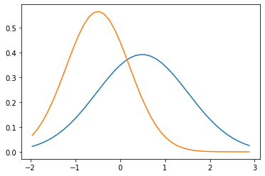

```python
import pandas
import numpy
import scipy.stats
import matplotlib.pyplot as plt

file_content = pandas.read_csv("advertising_dataset.csv")
# Replace NaNs
for i in file_content.columns[1:5]:
    file_content[i].fillna(file_content[i].mean(), inplace=True)
# Normalize
temp = file_content['Clicked on Ad']
file_content.drop(columns = ['Unnamed: 0', 'Ad Topic Line', 'City', 'Gender', 'Country', 'Timestamp'], inplace=True)
file_content = (file_content - file_content.mean()) / file_content.std()
file_content['Clicked on Ad'] = temp


mean_click = file_content.groupby('Clicked on Ad')['Age'].mean()[1]
mean_not_click = file_content.groupby('Clicked on Ad')['Age'].mean()[0]
std_click = file_content.groupby('Clicked on Ad')['Age'].std()[1]
std_not_click = file_content.groupby('Clicked on Ad')['Age'].std()[0]

norm_click = scipy.stats.norm(mean_click, std_click)
norm_not_click = scipy.stats.norm(mean_not_click, std_not_click)
x_axis = sorted(file_content['Age'])

print("Age: (BLUE: clicked, ORANGE: Not clicked)")
plt.plot(x_axis, norm_click.pdf(x_axis))
plt.plot(x_axis, norm_not_click.pdf(x_axis))
```

```
Area Income: (BLUE: clicked, ORANGE: Not clicked)
```

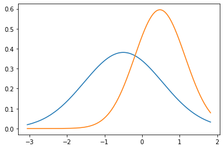

```python
import pandas
import numpy
import scipy.stats
import matplotlib.pyplot as plt

file_content = pandas.read_csv("advertising_dataset.csv")
# Replace NaNs
for i in file_content.columns[1:5]:
    file_content[i].fillna(file_content[i].mean(), inplace=True)
# Normalize
temp = file_content['Clicked on Ad']
file_content.drop(columns = ['Unnamed: 0', 'Ad Topic Line', 'City', 'Gender', 'Country', 'Timestamp'], inplace=True)
file_content = (file_content - file_content.mean()) / file_content.std()
file_content['Clicked on Ad'] = temp


mean_click = file_content.groupby('Clicked on Ad')['Area Income'].mean()[1]
mean_not_click = file_content.groupby('Clicked on Ad')['Area Income'].mean()[0]
std_click = file_content.groupby('Clicked on Ad')['Area Income'].std()[1]
std_not_click = file_content.groupby('Clicked on Ad')['Area Income'].std()[0]

norm_click = scipy.stats.norm(mean_click, std_click)
norm_not_click = scipy.stats.norm(mean_not_click, std_not_click)
x_axis = sorted(file_content['Area Income'])

print("Area Income: (BLUE: clicked, ORANGE: Not clicked)")
plt.plot(x_axis, norm_click.pdf(x_axis))
plt.plot(x_axis, norm_not_click.pdf(x_axis))
```

```
Daily Internet Usage: (BLUE: clicked, ORANGE: Not clicked)
```

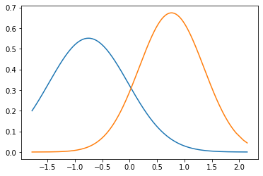

```python
import pandas
import numpy
import scipy.stats
import matplotlib.pyplot as plt

file_content = pandas.read_csv("advertising_dataset.csv")
# Replace NaNs
for i in file_content.columns[1:5]:
    file_content[i].fillna(file_content[i].mean(), inplace=True)
# Normalize
temp = file_content['Clicked on Ad']
file_content.drop(columns = ['Unnamed: 0', 'Ad Topic Line', 'City', 'Gender', 'Country', 'Timestamp'], inplace=True)
file_content = (file_content - file_content.mean()) / file_content.std()
file_content['Clicked on Ad'] = temp


mean_click = file_content.groupby('Clicked on Ad')['Daily Internet Usage'].mean()[1]
mean_not_click = file_content.groupby('Clicked on Ad')['Daily Internet Usage'].mean()[0]
std_click = file_content.groupby('Clicked on Ad')['Daily Internet Usage'].std()[1]
std_not_click = file_content.groupby('Clicked on Ad')['Daily Internet Usage'].std()[0]

norm_click = scipy.stats.norm(mean_click, std_click)
norm_not_click = scipy.stats.norm(mean_not_click, std_not_click)
x_axis = sorted(file_content['Daily Internet Usage'])

print("Daily Internet Usage: (BLUE: clicked, ORANGE: Not clicked)")
plt.plot(x_axis, norm_click.pdf(x_axis))
plt.plot(x_axis, norm_not_click.pdf(x_axis))
```

توجه کنید در تمامی نمودارهای بالا اگر داده ای موجود نبوده میانگین به جای آن استفاده شده است. (مانند قسمت سه)

# PART 11

```python
import pandas
import numpy
import scipy.stats
import matplotlib.pyplot as plt
pandas.options.mode.chained_assignment = None

normalized = pandas.read_csv("advertising_dataset.csv")
# Replace NaNs.
for i in normalized.columns[1:5]:
    normalized[i].fillna(normalized[i].mean(), inplace=True)
# Normalize one of files.
temp = normalized['Clicked on Ad']
normalized.drop(columns = ['Unnamed: 0', 'Ad Topic Line', 'City', 'Gender', 'Country', 'Timestamp'], inplace=True)
normalized = (file_content - normalized.mean()) / normalized.std()
normalized['Clicked on Ad'] = temp

mean_click = normalized.groupby('Clicked on Ad')['Daily Internet Usage'].mean()[1]
mean_not_click = normalized.groupby('Clicked on Ad')['Daily Internet Usage'].mean()[0]
std_click = normalized.groupby('Clicked on Ad')['Daily Internet Usage'].std()[1]
std_not_click = normalized.groupby('Clicked on Ad')['Daily Internet Usage'].std()[0]

norm_click = scipy.stats.norm(mean_click, std_click)
norm_not_click = scipy.stats.norm(mean_not_click, std_not_click)

d = {'index': [], 'Predicted Clicked on Ad': []}
result = pandas.DataFrame(data=d)

for i in range(1000):
    if normalized['Clicked on Ad'][i] != numpy.float64(0) and normalized['Clicked on Ad'][i] != numpy.float64(1):
        predict = -1
        if norm_click.pdf(normalized['Daily Internet Usage'][i]) > norm_not_click.pdf(normalized['Daily Internet Usage'][i]):
            predict = 1
        else:
            predict = 0

        d = {'index': [i], 'Predicted Clicked on Ad': [predict]}
        result = result.append(pandas.DataFrame(data=d))

result.to_csv('result.csv', index = False)
```